# Análisis Multivariado

- Mostrar todo el código
- Ocultar todo el código
- Ver el código fuente

Unidad II: Componentes Principales — Práctico

Autores/as

Pablo Ortiz

María Inés Stimolo

Fecha de publicación

22 de septiembre de 2026

# 1 Introducción

El **Análisis de Componentes Principales** (ACP) busca reducir la dimensionalidad de un conjunto de datos: a partir de $p$ variables originales, correlacionadas entre sí, construye $p$ nuevas variables —las *componentes principales*— que son combinaciones lineales de las originales, están incorrelacionadas entre sí, y se ordenan de mayor a menor variabilidad explicada. Si las primeras componentes concentran buena parte de la variabilidad, se puede trabajar con ellas en lugar de las $p$ variables originales sin perder demasiada información.

## 1.1 El conjunto de datos

Trabajamos con `indice.rda`: 50 empresas argentinas que cotizan en bolsa, con diez indicadores contables calculados a partir de sus estados financieros.

| Variable | Indicador | Cálculo |
| --- | --- | --- |
| `LIQACID` | Liquidez ácida | (Activo Cte. − Bienes de Cambio) / Pasivo Cte. |
| `SOLVENC` | Solvencia | Activo Total / Pasivo Total |
| `PROPACT` | Propiedad del activo | Patrimonio Neto / Activo |
| `PNOCOR` | Pasivo no corriente | Pasivo No Cte. / Activo |
| `AUTOFIN` | Autofinanciación | Utilidades no distribuidas / Activo |
| `INMACT` | Inmovilización del activo | Activo no corriente / Activo |
| `INMPN` | Inmovilización del P. Neto | Activo no corriente / Patrimonio Neto |
| `RENTECO` | Rentabilidad económica | Utilidad antes de impuestos / Activo Total |
| `MAREXP` | Margen de explotación | Utilidad Bruta / Ventas |
| `REXP_INT` | Costo marginal de financiamiento | Utilidad Neta / Intereses pagados |

Además, la variable `CONDICIO` clasifica a las empresas en dos grupos, que usaremos más adelante.

Como en la aplicación original, trabajamos con los **ocho primeros indicadores** (de `LIQACID` a `RENTECO`).

**TipMaterial del práctico**

Todo el código de este documento está disponible como script de R en el repositorio de la materia:

- [Descargar `Unidad2a_ACP.R`](https://raw.githubusercontent.com/pabort/MAE-Multivariado/main/Unidad2a_ACP.R) — clic derecho → “Guardar enlace como…”
- [Ver el repositorio completo](https://github.com/pabort/MAE-Multivariado)

El script está organizado en las mismas secciones que este documento, así que se puede navegar desde el índice de RStudio (Ctrl+Shift+O).

# 2 Carga de paquetes y datos

**Mostrar código**

```r
# Aseguramos codificación UTF-8, para evitar problemas con tildes y símbolos
# en los títulos de los gráficos generados por funciones de R base.
for (loc in c("es_AR.UTF-8", "es_ES.UTF-8", "en_US.UTF-8", "C.UTF-8", "C.utf8")) {
  if (Sys.setlocale("LC_CTYPE", loc) != "") break
}

library(factoextra)   # visualización y extracción de resultados de ACP
library(pcaPP)        # componentes principales robustas
library(MultiGroupO)  # componentes principales comunes
library(tidyverse)    # al final, para que dplyr::select() no quede enmascarado

theme_set(theme_minimal(base_size = 11))
```

Leemos los datos directamente desde el repositorio de la materia, de modo que el documento sea reproducible sin necesidad de descargar ningún archivo:

**Mostrar código**

```r
url_indice <- "https://raw.githubusercontent.com/pabort/MAE-Multivariado/main/indice.csv"
indice <- read_csv(url_indice, show_col_types = FALSE)

# Los nombres de empresa pasan a ser nombres de fila (para etiquetar los gráficos)
indice <- as.data.frame(indice)
rownames(indice) <- indice$EMPRESA
indice <- indice[, -1]

# Nos quedamos con los 8 primeros indicadores (LIQACID ... RENTECO)
indice8 <- indice[, 2:9]

dim(indice8)
```

```
[1] 50  8
```

**Mostrar código**

```r
head(indice8)
```

|  | LIQACID | SOLVENC | PROPACT | PNOCOR | AUTOFIN | INMACT | INMPN | RENTECO |
| --- | --- | --- | --- | --- | --- | --- | --- | --- |
| Bieckert95 | 44.63668 | 221.0182 | 54.75485 | 10.9745710 | -21.347113 | 77.94299 | 142.34902 | -12.7824997 |
| CVZA95 | 787.00955 | 1303.3462 | 92.32744 | 0.4534151 | 17.202037 | 35.45350 | 38.39974 | 0.3362886 |
| Grafex96 | 28.91074 | 158.8491 | 37.04717 | 10.9587179 | -20.369382 | 78.52363 | 211.95581 | -20.3693823 |
| BOLD96 | 107.20106 | 149.0278 | 32.89841 | 38.3757123 | 5.674057 | 65.61972 | 199.46170 | 5.7847071 |
| alpa_1996 | 647.85478 | 985.6998 | 89.85492 | 7.5442124 | 1.301781 | 82.85660 | 92.21153 | 1.3017814 |
| GRIM96 | 124.15654 | 252.7377 | 60.43328 | 0.0000000 | 11.227441 | 32.15251 | 53.20332 | 0.7043814 |

## 2.1 Exploración inicial

Antes de aplicar ACP conviene mirar dos cosas: si las variables están **correlacionadas** (si no lo estuvieran, no habría nada que resumir) y en qué **escalas** están medidas.

**Mostrar código**

```r
indice8 |>
  pivot_longer(everything(), names_to = "variable", values_to = "valor") |>
  group_by(variable) |>
  summarise(
    media    = mean(valor),
    de       = sd(valor),
    varianza = var(valor),
    minimo   = min(valor),
    maximo   = max(valor)
  )
```

| variable | media | de | varianza | minimo | maximo |
| --- | --- | --- | --- | --- | --- |
| AUTOFIN | -2.437780 | 22.73085 | 516.6913 | -60.926081 | 37.69275 |
| INMACT | 61.613622 | 18.26258 | 333.5220 | 31.672959 | 100.00000 |
| INMPN | 153.246871 | 102.27461 | 10460.0958 | 37.412967 | 595.15271 |
| LIQACID | 118.184418 | 170.93377 | 29218.3523 | 7.943548 | 791.62865 |
| PNOCOR | 11.801264 | 12.39312 | 153.5893 | 0.000000 | 45.11552 |
| PROPACT | 51.138574 | 20.84342 | 434.4480 | 7.787663 | 93.54084 |
| RENTECO | -4.304843 | 12.44732 | 154.9357 | -29.459297 | 33.55929 |
| SOLVENC | 293.521467 | 281.81224 | 79418.1360 | 108.445359 | 1548.18913 |

Las varianzas son enormemente dispares: `SOLVENC` y `LIQACID` tienen varianzas de decenas de miles, mientras que `PNOCOR` o `RENTECO` están en el orden de las centenas. Esto va a ser determinante a la hora de elegir entre trabajar con la matriz de covarianzas o la de correlación.

**Mostrar código**

```r
R <- cor(indice8)
round(R, 3)
```

```
        LIQACID SOLVENC PROPACT PNOCOR AUTOFIN INMACT  INMPN RENTECO
LIQACID   1.000   0.931   0.637 -0.163   0.174 -0.225 -0.374   0.113
SOLVENC   0.931   1.000   0.751 -0.318   0.185 -0.248 -0.452   0.150
PROPACT   0.637   0.751   1.000 -0.370   0.239 -0.115 -0.802   0.363
PNOCOR   -0.163  -0.318  -0.370  1.000  -0.265  0.530  0.365  -0.029
AUTOFIN   0.174   0.185   0.239 -0.265   1.000 -0.109 -0.241   0.565
INMACT   -0.225  -0.248  -0.115  0.530  -0.109  1.000  0.303  -0.061
INMPN    -0.374  -0.452  -0.802  0.365  -0.241  0.303  1.000  -0.388
RENTECO   0.113   0.150   0.363 -0.029   0.565 -0.061 -0.388   1.000
```

**Mostrar código**

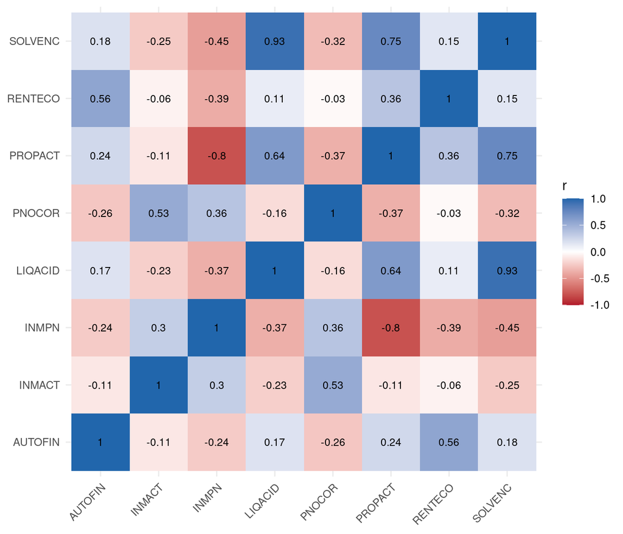

```r
R |>
  as_tibble(rownames = "var1") |>
  pivot_longer(-var1, names_to = "var2", values_to = "correlacion") |>
  ggplot(aes(var1, var2, fill = correlacion)) +
  geom_tile() +
  geom_text(aes(label = round(correlacion, 2)), size = 3) +
  scale_fill_gradient2(low = "#B2182B", mid = "white", high = "#2166AC",
                       midpoint = 0, limits = c(-1, 1)) +
  labs(x = NULL, y = NULL, fill = "r") +
  theme(axis.text.x = element_text(angle = 45, hjust = 1))
```

Hay bloques de variables fuertemente asociadas entre sí, que es justamente la situación donde el ACP resulta útil.

# 3 Las componentes paso a paso

Esta sección reproduce el cálculo “a mano” para ver de dónde salen las componentes. En la práctica se usa `prcomp()` (sección siguiente), pero conviene entender qué hace por dentro.

## 3.1 Fundamento geométrico: minimizar distancias es maximizar varianza

Antes de calcular nada, vale la pena entender **por qué** los autovectores de $\Sigma$ resuelven el problema del ACP. La idea es geométrica y no depende todavía de ningún cálculo matricial.

Sea $u$ una dirección cualquiera, de norma 1 ($u'u = 1$). Proyectar una observación centrada $x_i$ sobre $u$ arma un triángulo rectángulo: la hipotenusa es $\|x_i\|$, un cateto es la proyección $y_i = x_i'u$ (la coordenada de $x_i$ sobre la dirección $u$) y el otro cateto es el residuo $r_i$ (la distancia perpendicular de $x_i$ a la recta que genera $u$). Por Pitágoras,

$$\|x_i\|^2 = y_i^2 + r_i^2$$

Sumando sobre las $n$ observaciones,

$$\sum_{i=1}^n \|x_i\|^2 = \sum_{i=1}^n y_i^2 + \sum_{i=1}^n r_i^2$$

El lado izquierdo **no depende de $u$**: es una constante $C$ fija, determinada únicamente por los datos (la suma de las distancias al cuadrado de cada observación al origen). Entonces

$$\sum_i y_i^2 + \sum_i r_i^2 = C \qquad \Longrightarrow \qquad \text{maximizar } \sum_i y_i^2 \iff \text{minimizar } \sum_i r_i^2$$

Esta identidad es la razón por la que el ACP admite dos lecturas equivalentes, aunque históricamente se llegó a ellas por caminos distintos:

- **Pearson (1901)**: la recta que mejor aproxima la nube de puntos, minimizando la suma de los residuos al cuadrado.
- **Hotelling (1933)**: la dirección de máxima varianza proyectada.

Son el mismo problema, mirado desde los dos extremos de la misma identidad.

Se verifica probando varias direcciones sobre `indice8` estandarizado: tres aleatorias, un eje original y el primer autovector de la matriz de correlación. La suma $\sum y_i^2 + \sum r_i^2$ tiene que dar siempre la misma constante $C$, sea cual sea la dirección:

**Mostrar código**

```r
Xstd <- scale(indice8)   # datos estandarizados: cada variable con media 0 y varianza 1

C <- sum(rowSums(Xstd^2))   # suma de ||x_i||^2 sobre las n observaciones: no depende de u
C
```

```
[1] 392
```

**Mostrar código**

```r
proyectar <- function(u) {
  u  <- u / sqrt(sum(u^2))          # normalizar a norma 1
  y  <- as.numeric(Xstd %*% u)      # proyecciones sobre u
  r2 <- rowSums(Xstd^2) - y^2       # residuo al cuadrado, despejado de Pitágoras

  c(suma_y2 = sum(y^2), suma_r2 = sum(r2), suma_total = sum(y^2) + sum(r2))
}

set.seed(1)
direcciones <- list(
  aleatoria_1       = rnorm(ncol(Xstd)),
  aleatoria_2       = rnorm(ncol(Xstd)),
  aleatoria_3       = rnorm(ncol(Xstd)),
  eje_original_1    = c(1, rep(0, ncol(Xstd) - 1)),
  primer_autovector = eigen(cor(indice8))$vectors[, 1]
)

resultados <- map_dfr(direcciones, proyectar, .id = "direccion")
resultados
```

| direccion | suma_y2 | suma_r2 | suma_total |
| --- | --- | --- | --- |
| aleatoria_1 | 47.00316 | 344.9968 | 392 |
| aleatoria_2 | 24.69005 | 367.3099 | 392 |
| aleatoria_3 | 29.34850 | 362.6515 | 392 |
| eje_original_1 | 49.00000 | 343.0000 | 392 |
| primer_autovector | 173.79262 | 218.2074 | 392 |

**Mostrar código**

```r
stopifnot(isTRUE(all.equal(resultados$suma_total, rep(C, nrow(resultados)))))

range(resultados$suma_total)   # mínimo y máximo coinciden: es constante en las 5 direcciones
```

```
[1] 392 392
```

Y entre las direcciones probadas, el primer autovector es a la vez el que **maximiza** $\sum y_i^2$ y el que **minimiza** $\sum r_i^2$:

**Mostrar código**

```r
stopifnot(
  resultados$direccion[which.max(resultados$suma_y2)] == "primer_autovector",
  resultados$direccion[which.min(resultados$suma_r2)] == "primer_autovector"
)

c(direccion_maxima_varianza = resultados$direccion[which.max(resultados$suma_y2)],
  direccion_minimo_residuo  = resultados$direccion[which.min(resultados$suma_r2)])
```

```
direccion_maxima_varianza  direccion_minimo_residuo
      "primer_autovector"       "primer_autovector"
```

Esto no es casualidad entre las direcciones elegidas: es exactamente lo que garantiza la solución analítica del ACP —el autovector asociado al mayor autovalor es, entre *todas* las direcciones posibles, la que maximiza la varianza proyectada—, pero alcanza con compararlo contra un puñado de direcciones concretas para verlo en los datos.

Como los datos están centrados, $\sum_i y_i^2/(n-1)$ es la varianza muestral de la proyección $y$. Maximizar $\sum y_i^2$ equivale entonces, salvo esa constante $1/(n-1)$, a maximizar la varianza de la proyección — y ese máximo es justamente $\lambda_1$, el mayor autovalor de la matriz de correlación:

**Mostrar código**

```r
u1 <- eigen(cor(indice8))$vectors[, 1]
y1 <- as.numeric(Xstd %*% u1)

stopifnot(isTRUE(all.equal(var(y1), eigen(cor(indice8))$values[1])))

c(var_y1 = var(y1), lambda1 = eigen(cor(indice8))$values[1])
```

```
  var_y1  lambda1
3.546788 3.546788
```

## 3.2 Matriz de covarianzas y descomposición espectral

Las componentes se obtienen a partir de los valores y vectores propios de $\Sigma$ (estimada por $S$). Los autovalores se obtienen resolviendo

$$|\Sigma - \lambda I| = 0$$

y los autovectores asociados son aquellos tales que $(\Sigma - \lambda_i I)\,u_i = 0$. Como $\Sigma$ es simétrica y definida positiva, los $\lambda_i$ son reales y positivos, y se ordenan $\lambda_1 \geq \lambda_2 \geq \cdots \geq \lambda_p$. Los autovectores forman una matriz $U$ tal que

$$U' \Sigma U = \Delta = \text{diag}(\lambda_1, \ldots, \lambda_p)$$

**Mostrar código**

```r
S  <- cov(indice8)
eS <- eigen(S)

eS$values                    # autovalores
```

```
[1] 108174.54126   8626.74161   2800.73090    530.65922    351.84968
[6]    103.19766     68.23986     33.81023
```

**Mostrar código**

```r
round(eS$vectors, 3)         # autovectores (por columna)
```

```
       [,1]   [,2]   [,3]   [,4]   [,5]   [,6]   [,7]   [,8]
[1,] -0.498  0.222  0.835 -0.003  0.013  0.040  0.063 -0.015
[2,] -0.853  0.046 -0.515 -0.006 -0.009 -0.032 -0.062 -0.017
[3,] -0.048 -0.116 -0.036  0.001 -0.238  0.123  0.653  0.696
[4,]  0.011  0.040  0.078 -0.107 -0.344 -0.577 -0.533  0.496
[5,] -0.013 -0.044  0.018  0.942 -0.057  0.191 -0.223  0.147
[6,]  0.014  0.041 -0.007 -0.062 -0.897  0.283 -0.020 -0.331
[7,]  0.148  0.963 -0.174  0.067  0.012 -0.010  0.104  0.070
[8,] -0.006 -0.049  0.005  0.306 -0.129 -0.730  0.470 -0.365
```

## 3.3 Variabilidad explicada

Dos propiedades centrales, que verificamos numéricamente:

- **La varianza de cada componente es su autovalor**: $\text{Var}(Y_h) = \lambda_h$
- **Se conserva la variabilidad total**: $\text{tr}(\Sigma) = \sum_j \text{Var}(X_j) = \sum_j \lambda_j$

La proporción de variabilidad que explica la componente $h$ es entonces $\lambda_h / \sum_j \lambda_j$.

**Mostrar código**

```r
p  <- ncol(indice8)
VT <- sum(eS$values)

tibble(
  componente = paste0("CP", 1:p),
  autovalor  = eS$values,
  prop       = 100 * autovalor / VT,
  acumulada  = cumsum(prop)
)
```

| componente | autovalor | prop | acumulada |
| --- | --- | --- | --- |
| CP1 | 108174.54126 | 89.63024860 | 89.63025 |
| CP2 | 8626.74161 | 7.14786479 | 96.77811 |
| CP3 | 2800.73090 | 2.32060339 | 99.09872 |
| CP4 | 530.65922 | 0.43968865 | 99.53841 |
| CP5 | 351.84968 | 0.29153231 | 99.82994 |
| CP6 | 103.19766 | 0.08550655 | 99.91544 |
| CP7 | 68.23986 | 0.05654155 | 99.97199 |
| CP8 | 33.81023 | 0.02801417 | 100.00000 |

**Mostrar código**

```r
c(traza_S = sum(diag(S)), suma_autovalores = VT)
```

```
         traza_S suma_autovalores
        120689.8         120689.8
```

## 3.4 Cálculo de las componentes

Las componentes se obtienen proyectando los datos **centrados** sobre los autovectores:

$$Y = \tilde{X}\, U$$

**Mostrar código**

```r
Xdes <- scale(indice8, center = TRUE, scale = FALSE)  # matriz en desvíos
Y    <- Xdes %*% eS$vectors                            # componentes principales

round(Y[1:8, 1:3], 3)   # primeras 8 empresas, primeras 3 componentes
```

```
                [,1]     [,2]    [,3]
Bieckert95    97.199  -28.713 -22.830
CVZA95     -1214.011   77.266  56.144
Grafex96     169.240   34.362 -15.432
BOLD96       136.581   37.879  60.120
alpa_1996   -864.790   86.669  94.298
GRIM96        15.782 -100.509  42.646
Gottuz95     -16.262  -31.577 111.704
REGE95       122.262  -66.524 -36.287
```

Las componentes tienen media cero y conservan la variabilidad del conjunto original, tanto la total como la generalizada:

**Mostrar código**

```r
round(colMeans(Y), 10)   # medias ~ 0
```

```
[1] 0 0 0 0 0 0 0 0
```

**Mostrar código**

```r
c(varianza_total_X   = sum(diag(S)),
  varianza_total_Y   = sum(diag(var(Y))))
```

```
varianza_total_X varianza_total_Y
        120689.8         120689.8
```

**Mostrar código**

```r
c(varianza_generalizada_X = det(S),
  varianza_generalizada_Y = det(var(Y)))
```

```
varianza_generalizada_X varianza_generalizada_Y
           1.161909e+23            1.161909e+23
```

Además, las componentes están **incorrelacionadas** entre sí: su matriz de covarianzas es diagonal, con los autovalores en la diagonal.

**Mostrar código**

```r
round(var(Y), 4)
```

```
         [,1]     [,2]     [,3]     [,4]     [,5]     [,6]    [,7]    [,8]
[1,] 108174.5    0.000    0.000   0.0000   0.0000   0.0000  0.0000  0.0000
[2,]      0.0 8626.742    0.000   0.0000   0.0000   0.0000  0.0000  0.0000
[3,]      0.0    0.000 2800.731   0.0000   0.0000   0.0000  0.0000  0.0000
[4,]      0.0    0.000    0.000 530.6592   0.0000   0.0000  0.0000  0.0000
[5,]      0.0    0.000    0.000   0.0000 351.8497   0.0000  0.0000  0.0000
[6,]      0.0    0.000    0.000   0.0000   0.0000 103.1977  0.0000  0.0000
[7,]      0.0    0.000    0.000   0.0000   0.0000   0.0000 68.2399  0.0000
[8,]      0.0    0.000    0.000   0.0000   0.0000   0.0000  0.0000 33.8102
```

# 4 ACP sobre la matriz de covarianzas

`prcomp()` hace todo lo anterior en una línea. Por defecto trabaja sobre la matriz de covarianzas (`scale. = FALSE`).

**Mostrar código**

```r
pca_cov <- prcomp(indice8)
pca_cov
```

```
Standard deviations (1, .., p=8):
[1] 328.898983  92.880254  52.921932  23.036042  18.757656  10.158625   8.260742
[8]   5.814657

Rotation (n x k) = (8 x 8):
                 PC1         PC2          PC3          PC4          PC5
LIQACID  0.498122456 -0.22226510 -0.834576591 -0.002597657 -0.012668160
SOLVENC  0.852713924 -0.04617109  0.515174074 -0.006199585  0.009491023
PROPACT  0.047769119  0.11642880  0.036134350  0.001352032  0.238236690
PNOCOR  -0.011064818 -0.03978935 -0.077775317 -0.106936292  0.344040659
AUTOFIN  0.013340585  0.04437896 -0.018114439  0.941631817  0.056874044
INMACT  -0.014141290 -0.04120603  0.007213688 -0.062152009  0.896969847
INMPN   -0.148103297 -0.96293307  0.174119968  0.067155329 -0.012103341
RENTECO  0.006010758  0.04919429 -0.004996284  0.305735883  0.129200188
                 PC6         PC7         PC8
LIQACID -0.039756671 -0.06299145 -0.01544061
SOLVENC  0.032393882  0.06238003 -0.01654451
PROPACT -0.122706601 -0.65298508  0.69616936
PNOCOR   0.576868082  0.53301033  0.49554943
AUTOFIN -0.190643102  0.22296268  0.14684046
INMACT  -0.282544973  0.01957761 -0.33078290
INMPN    0.009561752 -0.10399333  0.07032205
RENTECO  0.730252332 -0.46983086 -0.36516052
```

**Mostrar código**

```r
summary(pca_cov)
```

```
Importance of components:
                            PC1      PC2      PC3     PC4      PC5      PC6
Standard deviation     328.8990 92.88025 52.92193 23.0360 18.75766 10.15862
Proportion of Variance   0.8963  0.07148  0.02321  0.0044  0.00292  0.00086
Cumulative Proportion    0.8963  0.96778  0.99099  0.9954  0.99830  0.99915
                           PC7     PC8
Standard deviation     8.26074 5.81466
Proportion of Variance 0.00057 0.00028
Cumulative Proportion  0.99972 1.00000
```

**Mostrar código**

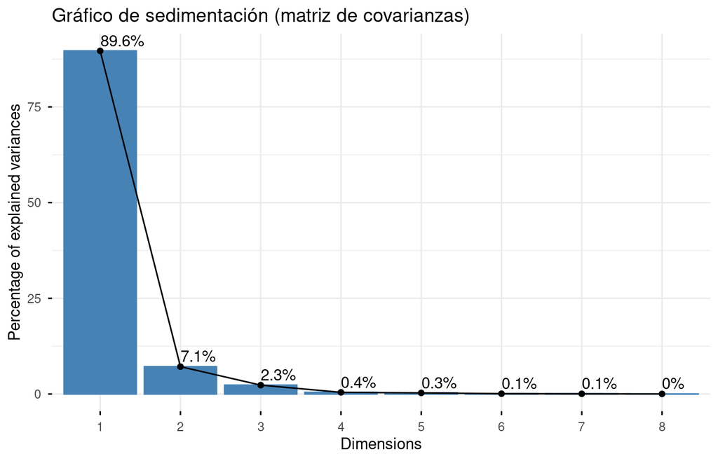

```r
fviz_eig(pca_cov, addlabels = TRUE,
         main = "Gráfico de sedimentación (matriz de covarianzas)")
```

**AdvertenciaUn resultado engañoso**

La primera componente explica casi el 90% de la variabilidad. Antes de celebrar, conviene mirar de dónde viene ese número:

**Mostrar código**

```r
tibble(
  variable = names(indice8),
  varianza = diag(S),
  aporte_pct = 100 * varianza / sum(varianza)
) |>
  arrange(desc(aporte_pct))
```

| variable | varianza | aporte_pct |
| --- | --- | --- |
| SOLVENC | 79418.1360 | 65.8035356 |
| LIQACID | 29218.3523 | 24.2094688 |
| INMPN | 10460.0958 | 8.6669282 |
| AUTOFIN | 516.6913 | 0.4281153 |
| PROPACT | 434.4480 | 0.3599708 |
| INMACT | 333.5220 | 0.2763465 |
| RENTECO | 154.9357 | 0.1283751 |
| PNOCOR | 153.5893 | 0.1272596 |

`SOLVENC` aporta por sí sola dos tercios de la varianza total y `LIQACID` casi un cuarto más. Como el ACP sobre covarianzas busca direcciones de máxima varianza, la primera componente termina siendo prácticamente `SOLVENC` disfrazada: no está resumiendo la estructura de los datos, está reflejando que esa variable se mide en una escala más grande que el resto.

# 5 ACP sobre la matriz de correlación

Para evitar ese problema se trabaja con las variables **estandarizadas**, lo que equivale a hacer el ACP sobre la matriz de correlación $R$. Con `prcomp()` se indica con `scale. = TRUE`.

Al estandarizar, $\text{tr}(R) = \sum_j \lambda_j^R = p$, de modo que la proporción explicada por la componente $h$ es simplemente $\lambda_h^R / p$.

**Mostrar código**

```r
pca_cor <- prcomp(indice8, scale. = TRUE)
summary(pca_cor)
```

```
Importance of components:
                          PC1    PC2    PC3     PC4    PC5     PC6     PC7
Standard deviation     1.8833 1.1874 1.1347 0.88107 0.7499 0.54418 0.28484
Proportion of Variance 0.4434 0.1762 0.1610 0.09704 0.0703 0.03702 0.01014
Cumulative Proportion  0.4434 0.6196 0.7805 0.87757 0.9479 0.98489 0.99503
                           PC8
Standard deviation     0.19946
Proportion of Variance 0.00497
Cumulative Proportion  1.00000
```

**Mostrar código**

```r
tibble(
  componente     = paste0("CP", 1:p),
  sobre_S_pct    = 100 * eS$values / sum(eS$values),
  sobre_R_pct    = 100 * pca_cor$sdev^2 / sum(pca_cor$sdev^2)
) |>
  mutate(across(where(is.numeric), ~round(.x, 2)))
```

| componente | sobre_S_pct | sobre_R_pct |
| --- | --- | --- |
| CP1 | 89.63 | 44.33 |
| CP2 | 7.15 | 17.62 |
| CP3 | 2.32 | 16.10 |
| CP4 | 0.44 | 9.70 |
| CP5 | 0.29 | 7.03 |
| CP6 | 0.09 | 3.70 |
| CP7 | 0.06 | 1.01 |
| CP8 | 0.03 | 0.50 |

El cambio es drástico: sobre covarianzas la primera componente parecía explicar casi todo (89.6%), mientras que sobre correlación explica un 44.3% y hacen falta varias componentes para llegar a un porcentaje razonable. Esta segunda lectura es la informativa, porque ahora todas las variables entran con el mismo peso.

**Nota¿Cuándo usar cada una?**

Como regla práctica: si las variables tienen **unidades distintas o escalas muy dispares**, se trabaja con la matriz de correlación. Solo cuando todas las variables están medidas en las mismas unidades y sus varianzas son comparables tiene sentido usar la matriz de covarianzas. En este ejemplo, aunque todos los indicadores son ratios contables, sus rangos de variación difieren en órdenes de magnitud, así que la opción adecuada es $R$.

De acá en adelante trabajamos con `pca_cor`.

## 5.1 Selección del número de componentes

La teórica presenta tres criterios:

1. **Gráfico de sedimentación**: retener las componentes hasta donde la pendiente empieza a nivelarse (el “codo”).
2. **Porcentaje acumulado**: retener hasta cubrir un porcentaje determinado de la varianza.
3. **Cota mínima**: retener las componentes con autovalor por encima de la varianza media. Con variables estandarizadas esa cota es $\lambda \geq 1$ (criterio de Kaiser).

**Mostrar código**

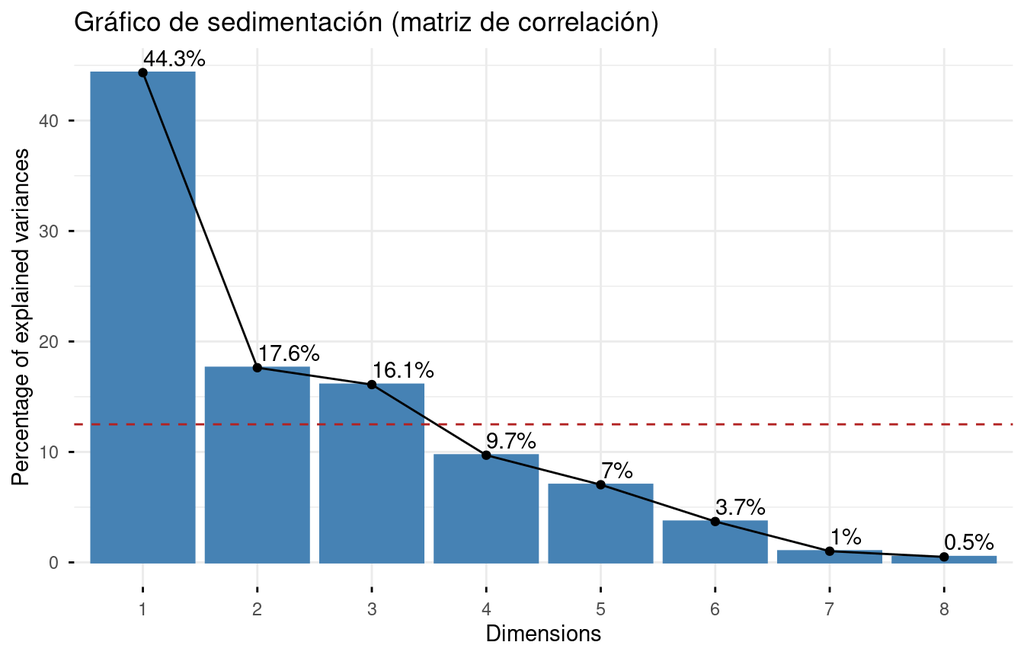

```r
fviz_eig(pca_cor, addlabels = TRUE, ncp = p,
         main = "Gráfico de sedimentación (matriz de correlación)") +
  geom_hline(yintercept = 100 / p, linetype = "dashed", colour = "firebrick")
```

La línea punteada marca el 12.5% ($=100/p$), que corresponde a un autovalor de 1: es el criterio de Kaiser expresado en porcentaje.

**Mostrar código**

```r
tibble(
  componente = paste0("CP", 1:p),
  autovalor  = pca_cor$sdev^2,
  prop_pct   = 100 * autovalor / p,
  acumulada  = cumsum(prop_pct),
  kaiser     = ifelse(autovalor >= 1, "retener", "descartar")
)
```

| componente | autovalor | prop_pct | acumulada | kaiser |
| --- | --- | --- | --- | --- |
| CP1 | 3.54678810 | 44.3348513 | 44.33485 | retener |
| CP2 | 1.40988079 | 17.6235099 | 61.95836 | retener |
| CP3 | 1.28763069 | 16.0953837 | 78.05374 | retener |
| CP4 | 0.77628379 | 9.7035474 | 87.75729 | descartar |
| CP5 | 0.56236804 | 7.0296004 | 94.78689 | descartar |
| CP6 | 0.29612919 | 3.7016149 | 98.48851 | descartar |
| CP7 | 0.08113447 | 1.0141809 | 99.50269 | descartar |
| CP8 | 0.03978492 | 0.4973115 | 100.00000 | descartar |

Los tres criterios apuntan a un número parecido de componentes; en lo que sigue trabajamos con las primeras dos o tres, según lo que permita la visualización.

## 5.2 Interpretación de las cargas

Los autovectores (o *cargas*) indican con qué peso entra cada variable original en cada componente. Es lo que permite darle un nombre o interpretación sustantiva a cada eje.

**Mostrar código**

```r
round(pca_cor$rotation[, 1:4], 3)
```

```
           PC1    PC2    PC3    PC4
LIQACID  0.407 -0.337 -0.275 -0.392
SOLVENC  0.449 -0.317 -0.207 -0.273
PROPACT  0.471 -0.045 -0.207  0.353
PNOCOR  -0.283  0.033 -0.613 -0.031
AUTOFIN  0.235  0.589  0.040 -0.488
INMACT  -0.225  0.101 -0.659  0.158
INMPN   -0.413 -0.105 -0.023 -0.619
RENTECO  0.235  0.644 -0.165  0.006
```

**Mostrar código**

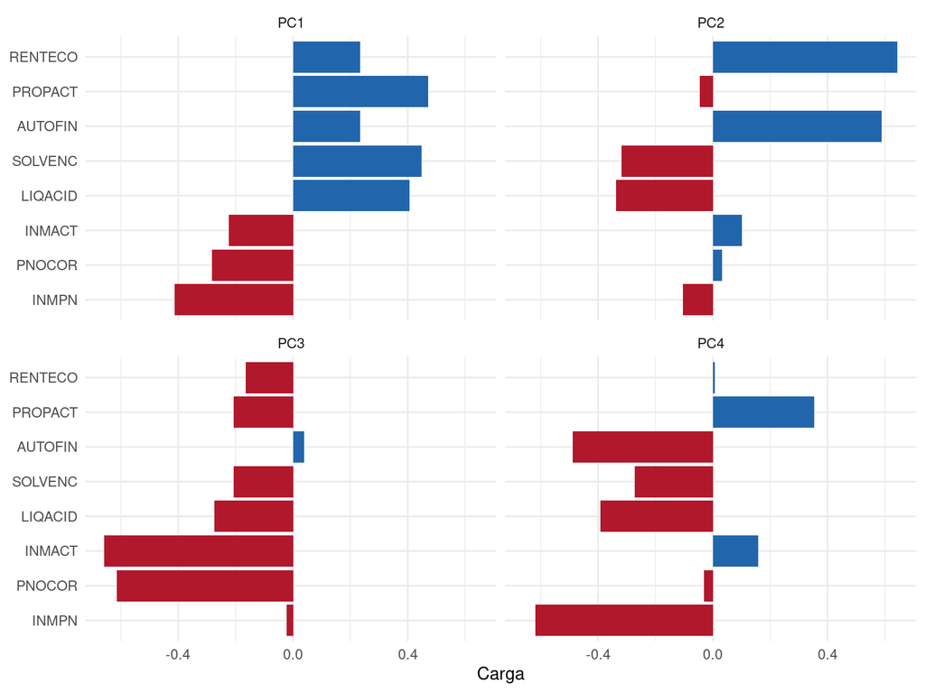

```r
pca_cor$rotation[, 1:4] |>
  as_tibble(rownames = "variable") |>
  pivot_longer(-variable, names_to = "componente", values_to = "carga") |>
  ggplot(aes(x = reorder(variable, carga), y = carga, fill = carga > 0)) +
  geom_col() +
  coord_flip() +
  facet_wrap(~componente) +
  scale_fill_manual(values = c("TRUE" = "#2166AC", "FALSE" = "#B2182B")) +
  labs(x = NULL, y = "Carga", fill = "Signo positivo") +
  theme(legend.position = "none")
```

## 5.3 Correlaciones entre variables y componentes

La covarianza entre una variable y una componente es

$$\text{Cov}(X_l, Y_k) = \lambda_k\, u_{lk}$$

y la correlación correspondiente,

$$\text{Corr}(X_l, Y_k) = \frac{\sqrt{\lambda_k}\; u_{lk}}{\sqrt{s_{ll}}}$$

Cuando las variables están estandarizadas ($s_{ll} = 1$), esto se simplifica a $\text{Corr}(X_l, Y_k) = \sqrt{\lambda_k}\, u_{lk}$.

**Mostrar código**

```r
U  <- pca_cor$rotation
Ds <- diag(pca_cor$sdev)      # raíces de los autovalores

CorZY <- U %*% Ds
dimnames(CorZY) <- list(names(indice8), paste0("CP", 1:p))

round(CorZY[, 1:4], 3)
```

```
           CP1    CP2    CP3    CP4
LIQACID  0.766 -0.401 -0.312 -0.346
SOLVENC  0.845 -0.377 -0.234 -0.240
PROPACT  0.887 -0.054 -0.234  0.311
PNOCOR  -0.534  0.039 -0.696 -0.028
AUTOFIN  0.442  0.699  0.045 -0.430
INMACT  -0.423  0.120 -0.747  0.139
INMPN   -0.778 -0.125 -0.026 -0.545
RENTECO  0.443  0.765 -0.188  0.006
```

Elevando esas correlaciones al cuadrado se obtiene una tabla con dos lecturas complementarias:

- **Por filas**: qué proporción de la variabilidad de cada variable queda recogida por cada componente. Es la **calidad de representación** de la variable (también llamada $\cos^2$). La suma de toda la fila da 1.
- **Por columnas**: cuánto aporta cada variable a la construcción de cada componente. Es la **contribución** de la variable a esa componente. La suma de la columna da el autovalor correspondiente.

**Mostrar código**

```r
CorZY2 <- CorZY^2

# Calidad de representación acumulada en las primeras 3 componentes
tibble(
  variable = names(indice8),
  CP1 = CorZY2[, 1],
  CP2 = CorZY2[, 2],
  CP3 = CorZY2[, 3],
  acumulado_3CP = CP1 + CP2 + CP3,
  suma_fila_total = rowSums(CorZY2)
) |>
  mutate(across(where(is.numeric), ~round(.x, 3)))
```

| variable | CP1 | CP2 | CP3 | acumulado_3CP | suma_fila_total |
| --- | --- | --- | --- | --- | --- |
| LIQACID | 0.587 | 0.160 | 0.097 | 0.844 | 1 |
| SOLVENC | 0.714 | 0.142 | 0.055 | 0.911 | 1 |
| PROPACT | 0.786 | 0.003 | 0.055 | 0.844 | 1 |
| PNOCOR | 0.285 | 0.002 | 0.484 | 0.771 | 1 |
| AUTOFIN | 0.195 | 0.488 | 0.002 | 0.686 | 1 |
| INMACT | 0.179 | 0.014 | 0.559 | 0.752 | 1 |
| INMPN | 0.605 | 0.016 | 0.001 | 0.621 | 1 |
| RENTECO | 0.196 | 0.585 | 0.035 | 0.816 | 1 |

**Mostrar código**

```r
# La suma por columnas devuelve los autovalores
tibble(
  componente = paste0("CP", 1:p),
  suma_columna = colSums(CorZY2),
  autovalor    = pca_cor$sdev^2
) |>
  mutate(across(where(is.numeric), ~round(.x, 4)))
```

| componente | suma_columna | autovalor |
| --- | --- | --- |
| CP1 | 3.5468 | 3.5468 |
| CP2 | 1.4099 | 1.4099 |
| CP3 | 1.2876 | 1.2876 |
| CP4 | 0.7763 | 0.7763 |
| CP5 | 0.5624 | 0.5624 |
| CP6 | 0.2961 | 0.2961 |
| CP7 | 0.0811 | 0.0811 |
| CP8 | 0.0398 | 0.0398 |

`factoextra` calcula lo mismo directamente, expresando las contribuciones en porcentaje:

**Mostrar código**

```r
var_info <- get_pca_var(pca_cor)

round(var_info$cos2[, 1:3], 3)      # calidad de representación
```

```
        Dim.1 Dim.2 Dim.3
LIQACID 0.587 0.160 0.097
SOLVENC 0.714 0.142 0.055
PROPACT 0.786 0.003 0.055
PNOCOR  0.285 0.002 0.484
AUTOFIN 0.195 0.488 0.002
INMACT  0.179 0.014 0.559
INMPN   0.605 0.016 0.001
RENTECO 0.196 0.585 0.035
```

**Mostrar código**

```r
round(var_info$contrib[, 1:3], 2)   # contribuciones (%)
```

```
        Dim.1 Dim.2 Dim.3
LIQACID 16.54 11.38  7.54
SOLVENC 20.14 10.07  4.27
PROPACT 22.16  0.20  4.27
PNOCOR   8.03  0.11 37.59
AUTOFIN  5.51 34.64  0.16
INMACT   5.04  1.02 43.38
INMPN   17.05  1.10  0.05
RENTECO  5.53 41.47  2.74
```

**Mostrar código**

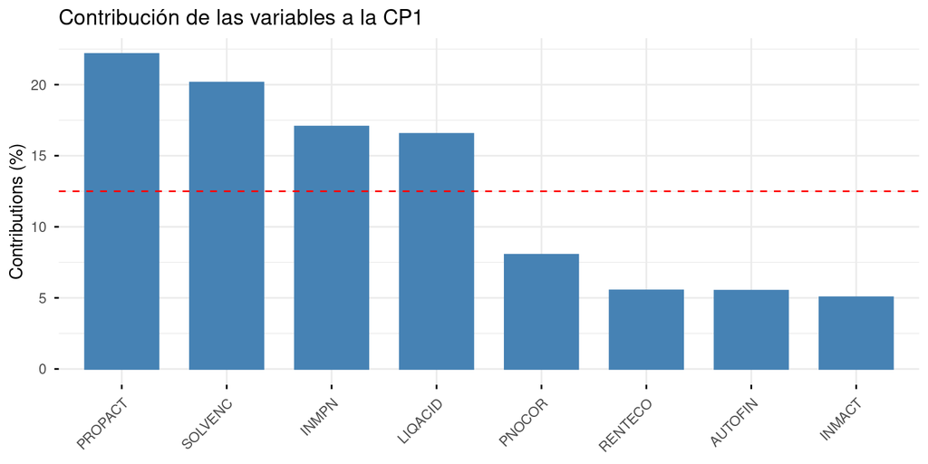

```r
fviz_contrib(pca_cor, choice = "var", axes = 1) +
  labs(title = "Contribución de las variables a la CP1")
```

**Mostrar código**

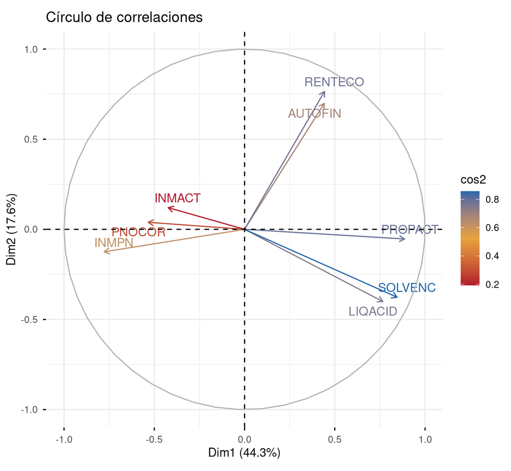

```r
fviz_pca_var(pca_cor, col.var = "cos2", repel = TRUE,
             gradient.cols = c("#B2182B", "#E8A33D", "#2166AC")) +
  labs(title = "Círculo de correlaciones")
```

En el círculo de correlaciones, cada variable se representa por un vector: su longitud indica qué tan bien queda representada en el plano de las dos primeras componentes, y el ángulo entre dos vectores aproxima su correlación (ángulos chicos, correlación alta; ángulos rectos, correlación cercana a cero; sentidos opuestos, correlación negativa).

## 5.4 Biplot

El biplot superpone, en un mismo gráfico, las observaciones y las variables proyectadas en el plano de dos componentes.

**Mostrar código**

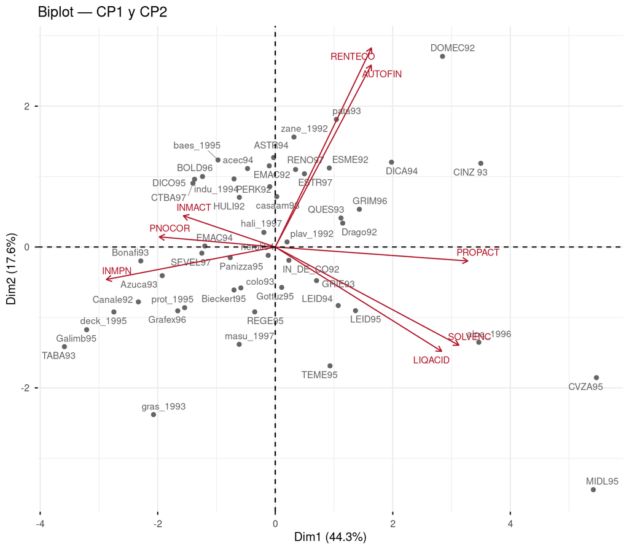

```r
fviz_pca_biplot(pca_cor, repel = TRUE,
                col.var = "#B2182B", col.ind = "grey40",
                labelsize = 3) +
  labs(title = "Biplot — CP1 y CP2")
```

Coloreando las observaciones según `CONDICIO` se puede ver si los grupos se distinguen en el espacio de las componentes:

**Mostrar código**

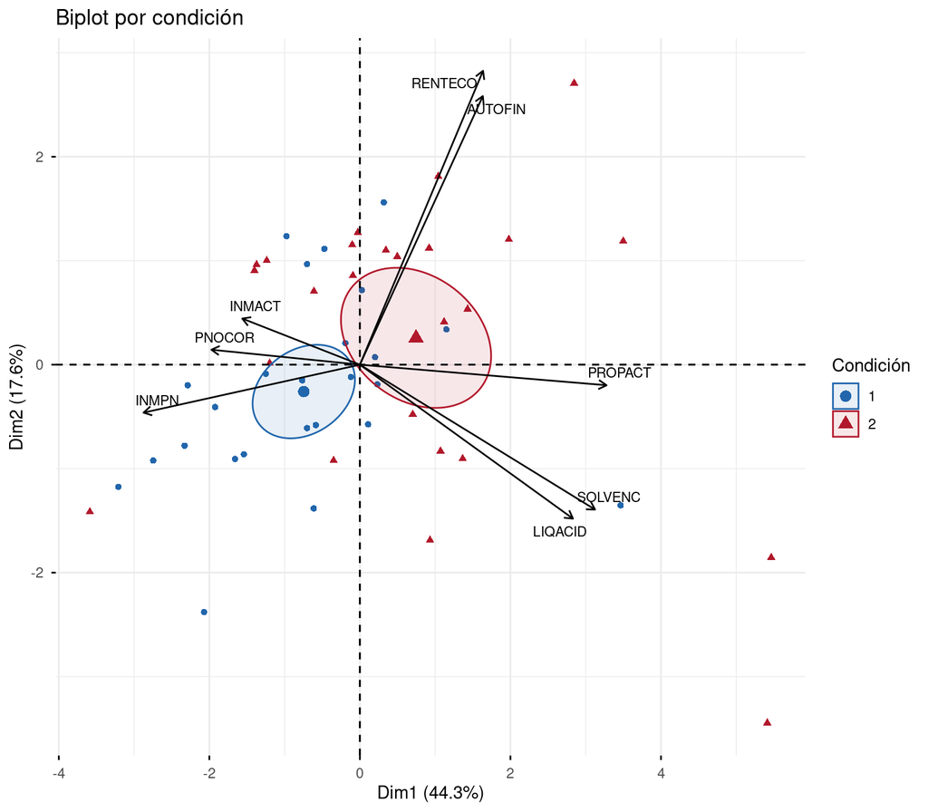

```r
grupo <- factor(indice$CONDICIO)

fviz_pca_biplot(pca_cor, repel = TRUE,
                col.ind = grupo, palette = c("#2166AC", "#B2182B"),
                addEllipses = TRUE, ellipse.type = "confidence",
                legend.title = "Condición",
                label = "var", col.var = "black", labelsize = 3) +
  labs(title = "Biplot por condición")
```

También pueden explorarse otros planos factoriales:

**Mostrar código**

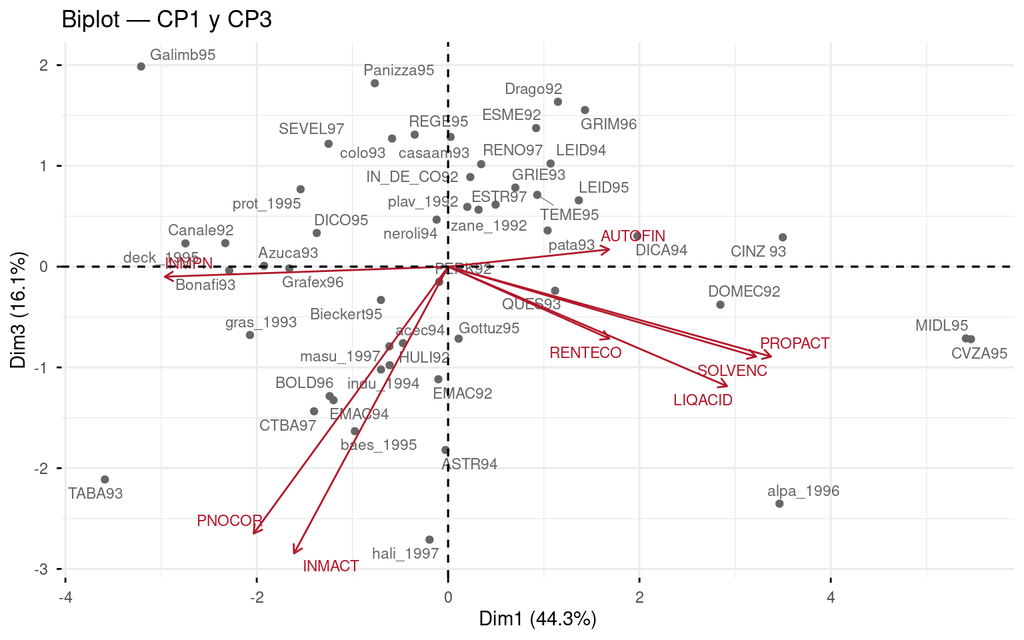

```r
fviz_pca_biplot(pca_cor, axes = c(1, 3), repel = TRUE,
                col.var = "#B2182B", col.ind = "grey40", labelsize = 3) +
  labs(title = "Biplot — CP1 y CP3")
```

# 6 Componentes principales robustas

El ACP clásico se apoya en la matriz de covarianzas, que es muy sensible a valores atípicos: unas pocas observaciones extremas pueden inclinar la dirección de las primeras componentes. Las **componentes robustas** reemplazan la varianza por una medida de dispersión resistente —por ejemplo el cuadrado de la desviación absoluta mediana (MAD) o del rango intercuartílico— y buscan las direcciones que maximizan esa medida:

$$\hat{\lambda}_k = \arg\max_{\|u\|=1,\; u \perp u_1, \ldots, u \perp u_{k-1}} V(u'X)$$

donde $V$ es el índice de proyección elegido.

**Mostrar código**

```r
pca_rob <- PCAproj(indice8, k = 6, method = "mad",
                   CalcMethod = "eachobs",
                   center = l1median_NLM, scale = "mad")

summary(pca_rob)
```

```
Importance of components:
                          Comp.1    Comp.2    Comp.3     Comp.4     Comp.5
Standard deviation     2.1620434 1.6866369 1.5421897 1.09688306 0.80138167
Proportion of Variance 0.3847532 0.2341513 0.1957623 0.09903165 0.05286061
Cumulative Proportion  0.3847532 0.6189045 0.8146667 0.91369837 0.96655898
                           Comp.6
Standard deviation     0.63740145
Proportion of Variance 0.03344102
Cumulative Proportion  1.00000000
```

**Mostrar código**

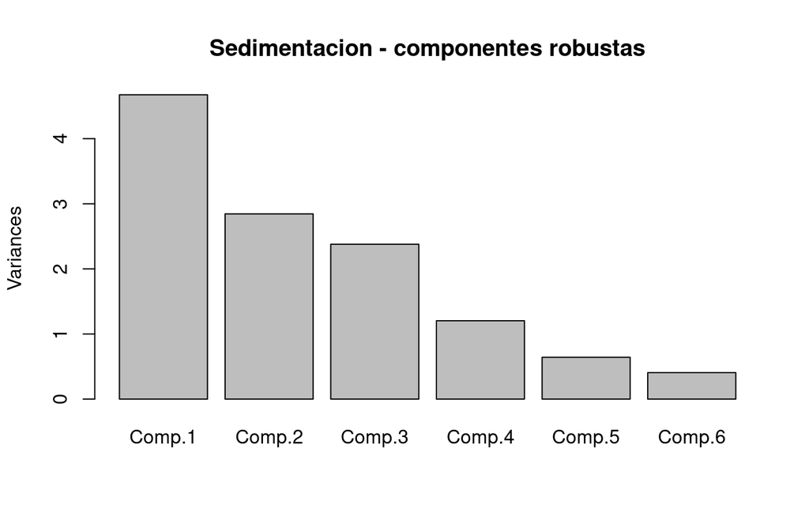

```r
screeplot(pca_rob, main = "Sedimentacion - componentes robustas")
```

**Mostrar código**

```r
round(unclass(pca_rob$loadings)[, 1:4], 3)
```

```
        Comp.1 Comp.2 Comp.3 Comp.4
LIQACID  0.525 -0.149  0.287 -0.555
SOLVENC  0.487 -0.198  0.315  0.169
PROPACT  0.361 -0.039  0.088  0.468
PNOCOR  -0.223  0.263  0.752 -0.158
AUTOFIN  0.123  0.679 -0.236 -0.081
INMACT  -0.164  0.090  0.370  0.592
INMPN   -0.446 -0.038  0.219 -0.249
RENTECO  0.257  0.630  0.072  0.004
```

**Mostrar código**

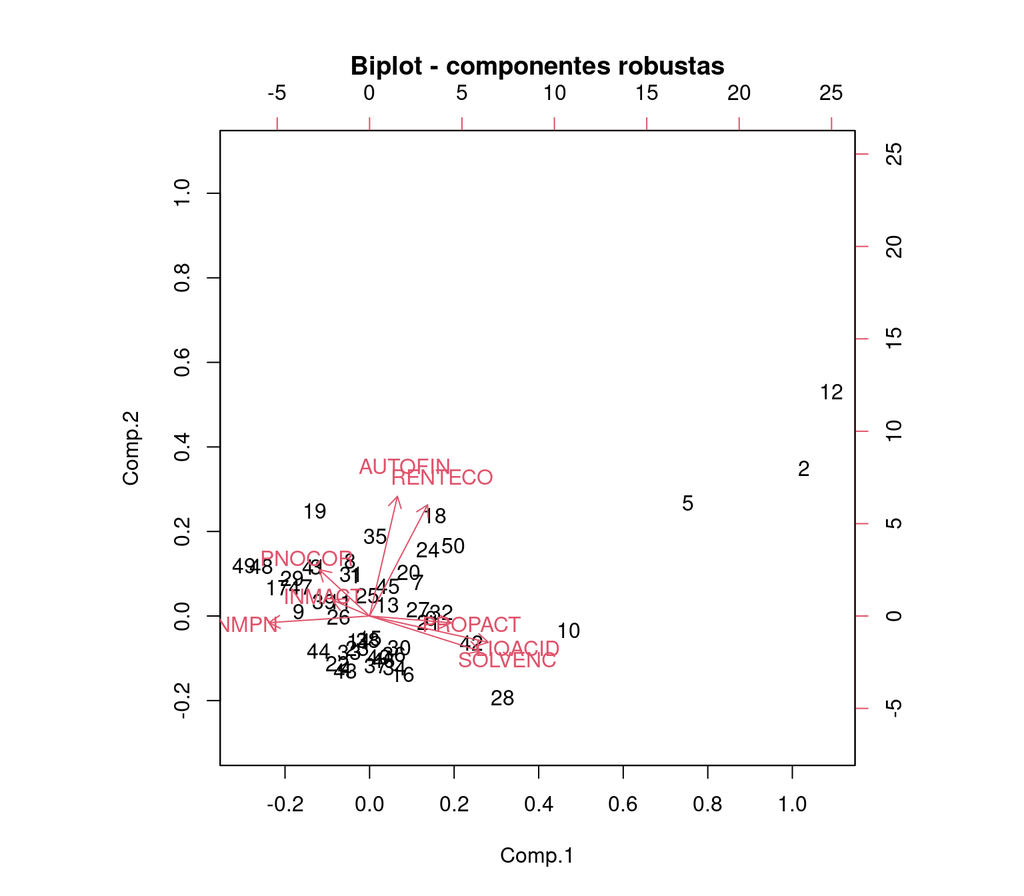

```r
biplot(pca_rob, main = "Biplot - componentes robustas")
```

Comparando las cargas de la primera componente robusta con las de la clásica se puede evaluar cuánto influían los valores extremos en la solución original:

**Mostrar código**

```r
tibble(
  variable = names(indice8),
  clasica  = pca_cor$rotation[, 1],
  robusta  = unclass(pca_rob$loadings)[, 1]
) |>
  mutate(across(where(is.numeric), ~round(.x, 3)))
```

| variable | clasica | robusta |
| --- | --- | --- |
| LIQACID | 0.407 | 0.525 |
| SOLVENC | 0.449 | 0.487 |
| PROPACT | 0.471 | 0.361 |
| PNOCOR | -0.283 | -0.223 |
| AUTOFIN | 0.235 | 0.123 |
| INMACT | -0.225 | -0.164 |
| INMPN | -0.413 | -0.446 |
| RENTECO | 0.235 | 0.257 |

# 7 Componentes principales comunes

Cuando los datos están divididos en $M$ grupos, cabe preguntarse si es posible encontrar un **conjunto único de direcciones** que sirva para todos ellos. El modelo de componentes principales comunes, propuesto por Flury (1984), asume que las matrices de covarianza de los grupos son conmutables —es decir, diagonalizables simultáneamente— y descompone cada una como

$$\Sigma_m = U \Lambda_m U' \qquad \text{con } UU' = I, \quad m = 1, \ldots, M$$

Es decir: los autovectores $U$ son **comunes** a todos los grupos, y lo que cambia entre ellos son los autovalores $\Lambda_m$, o sea la importancia relativa de cada dirección dentro de cada grupo.

**Mostrar código**

```r
x     <- indice8
grupo <- factor(indice$CONDICIO)

table(grupo)
```

```
grupo
 1  2
25 25
```

**Mostrar código**

```r
# Matriz a diagonalizar simultáneamente
mat_diag <- new.cov(x, cls = grupo, A = diag(ncol(x)))

res_mgpca <- mgpca(mat_diag, as.matrix(x), cls = grupo,
                   Plot = FALSE, ncomp = 2,
                   center = TRUE, scale = TRUE)

names(res_mgpca)
```

```
[1] "variates"      "loadings"      "prop_expl_var"
```

**Mostrar código**

```r
# Porcentaje de varianza recuperada por cada dimensión común
res_mgpca$prop_expl_var
```

```
[1] 26.42 13.03
```

**Mostrar código**

```r
# Cargas comunes a todos los grupos
cargas_comunes <- res_mgpca$loadings
dimnames(cargas_comunes) <- list(names(indice8), paste0("Dim", 1:ncol(cargas_comunes)))

round(cargas_comunes[, 1:2], 3)
```

```
          Dim1   Dim2
LIQACID -0.486  0.270
SOLVENC -0.856  0.043
PROPACT -0.051 -0.119
PNOCOR   0.011  0.036
AUTOFIN -0.018 -0.056
INMACT   0.016  0.045
INMPN    0.168  0.949
RENTECO -0.009 -0.057
```

**Mostrar código**

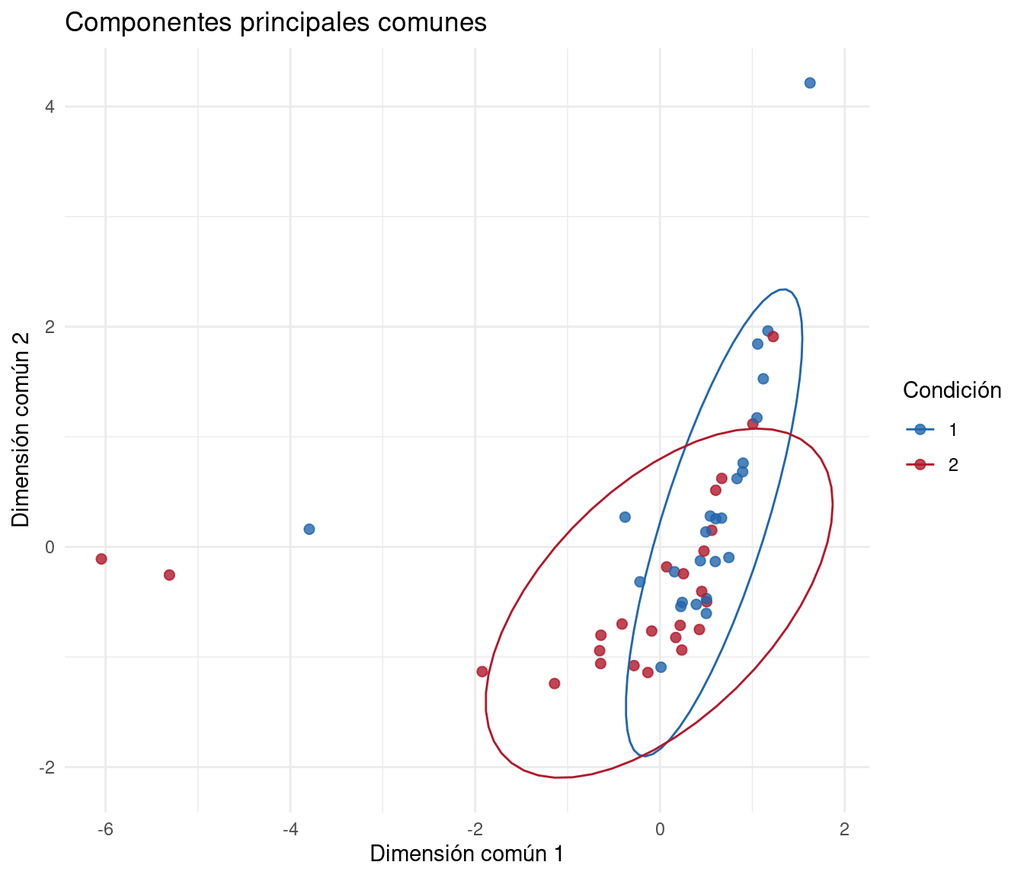

```r
# Coordenadas de las observaciones sobre las dos primeras dimensiones comunes
tibble(
  Dim1  = res_mgpca$variates[, 1],
  Dim2  = res_mgpca$variates[, 2],
  grupo = grupo
) |>
  ggplot(aes(Dim1, Dim2, colour = grupo)) +
  geom_point(size = 2, alpha = 0.8) +
  stat_ellipse(level = 0.95) +
  scale_colour_manual(values = c("#2166AC", "#B2182B")) +
  labs(title = "Componentes principales comunes",
       x = "Dimensión común 1", y = "Dimensión común 2",
       colour = "Condición")
```

# 8 Referencias

- Peña, D. (2002). *Análisis de Datos Multivariantes*. McGraw-Hill.
- Johnson, R. A. y Wichern, D. W. (1998). *Applied Multivariate Statistical Analysis*.
- Flury, B. N. (1984). Common principal components in $k$ groups. *Journal of the American Statistical Association*, 79(388), 892–898.
- Croux, C., Filzmoser, P. y Fritz, H. (2013). Robust sparse principal component analysis. *Technometrics*, 55(2), 202–214.